# Chess Elo Prediction — v4

Predicting White and Black Elo ratings from chess game data using a multi-task neural network. The model combines hand-crafted board/clock features with optional sequence embeddings from a pre-trained autoencoder, and outputs a full probability distribution over rating ranges rather than a single number.

**Pipeline overview:**

1. Stream and filter games from a Lichess `.pgn.zst` database
2. Extract board features (python-chess replay) and clock features — both cached to disk
3. Optionally train a sequence autoencoder and cache its embeddings
4. Train a multi-task MLP (or MLP + AE) with KL-divergence loss against soft Gaussian targets
5. Evaluate on held-out test set and visualise results
6. Run inference on a single pasted PGN game

## Config

All settings in one place. The comments explain what each flag does and what to change for laptop vs GPU.

```
Device : cpu  |  AMP : False  |  CPU threads : 14
Sequential=False  |  AE=True  |  DistTarget=True
MAX_GAMES=2,000,000  |  BATCH=128  |  LR=0.0003  |  DROPOUT=0.3
Time control filter: None  |  Min plies: 12  |  Max seq len: 120
HPO enabled
```

## Data Loading

Stream-parse the compressed PGN file. We read line by line rather than loading everything into memory, which is important for multi-million game files.

```
Loaded 2,000,000 games in 502.0s
Removed 677,622 games by termination type
Kept 247,725 games after filters (removed 1,068,884)
Elo range — White: 775–2586,  Black: 762–2552
```

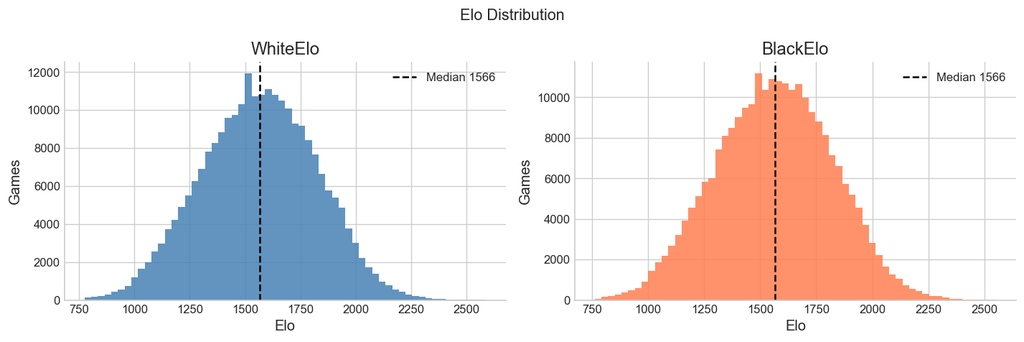

## Feature Extraction

Board features require replaying every game move-by-move with python-chess, which is slow. Both board and clock features are cached to disk — if the cache exists they load instantly.

```
Extracting board features (this runs once then caches)...
  Done in 398s — 35 cols
Extracting clock features...
  Done in 43s — 10 cols
Full feature matrix: (247725, 69)
```

## Move Tokenisation

Each unique chess move (e.g. `e4`, `Nf3`, `O-O`) gets assigned an integer ID. This is needed for the sequence model and autoencoder.

```
Dropped 4,061 games shorter than 12 plies
Vocabulary size : 8,855
Games ready     : 243,664
```

## Soft Distribution Targets

Rather than treating Elo prediction as a regression to a single number, we model each player's strength as a Gaussian distribution centred on their rating (σ=200). This reflects the real game-to-game variance in how a player performs — a 1600-rated player sometimes plays like a 1400, sometimes like an 1800.

The model outputs a 40-bin probability distribution over the range 0–4000. The point estimate is the weighted mean of that distribution. Training uses KL-divergence between predicted and target distributions.

```
1600 Elo dist: peak at 1550,  recovered = 1600
```

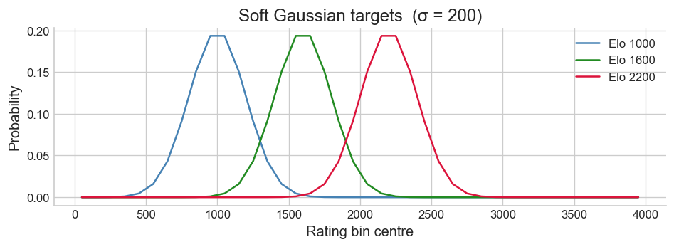

## Feature Selection, Train/Val/Test Split & Scaling

The split is stratified by Elo bracket so every rating range appears proportionally in all three sets. The scaler is fit on training data only — no information from val or test leaks into the scaling.

```
Static feature columns selected: 45
  [on ] game_structure      (3 cols)
  [on ] checks              (4 cols)
  [on ] captures            (5 cols)
  [on ] castling            (2 cols)
  [on ] style               (9 cols)
  [on ] engine_quality      (10 cols)
  [on ] clock               (10 cols)
  [on ] tc_meta             (2 cols)

Split — train: 194,931  val: 24,366  test: 24,367
Scaling done (StandardScaler fit on train only)
```

## Sequence Autoencoder

The autoencoder compresses each game's move sequence into a fixed-size vector (32 dimensions by default). It's trained once on a sample of games, then used to encode all games, and the resulting vectors are saved to disk. During main model training these cached vectors are used as extra static features, so we get sequence information without the cost of running an LSTM every training batch.

Architecture: BiLSTM encoder → 32-d bottleneck → LSTM decoder with teacher forcing.

```
Training sequence autoencoder...
  AE epoch 1/2  loss=6.8033
  AE epoch 2/2  loss=6.0681
AE embeddings saved: (243664, 32)
AE embeddings ready — 32 dims per game
```

## Dataset & DataLoaders

```
Building datasets...
  Built in 371s   total static dim = 77
Batches per epoch: 1,523
```

## Model

The model has two branches that get concatenated before prediction:

**Static branch:** MLP over board + clock features (+ AE embeddings if enabled). Uses LayerNorm and GELU activations which work well for tabular data.

**Sequence branch (optional):** Embedding → BiLSTM → soft attention pooling. Each move is represented as [embedding | normalised clock | turn flag].

**Output:** Two heads (White and Black), each predicting a softmax over 40 rating bins.

```
Model built — 1,268,465 trainable parameters
```

```
Running hyperparameter search — 20 trials on 50,000 games...
```

```
Best val loss: 0.9183
Best hyperparameters:
  lr              = 0.000833737294524746
  dropout         = 0.10257400414156334
  hidden_dim      = 128
  embed_dim       = 64
  batch_size      = 128
  weight_decay    = 6.550467844868409e-05
```

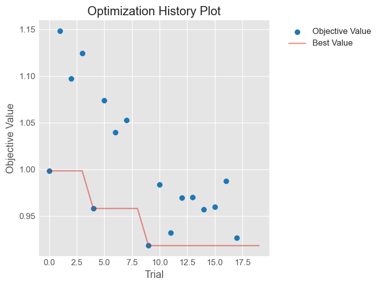

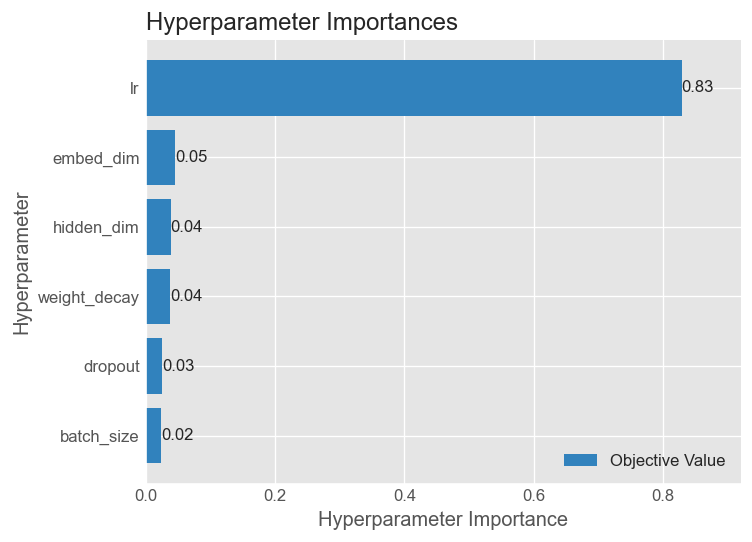

## Training

```
Using HPO parameters:
  lr              = 0.000833737294524746
  dropout         = 0.10257400414156334
  hidden_dim      = 128
  embed_dim       = 64
  batch_size      = 128
  weight_decay    = 6.550467844868409e-05
Model rebuilt — 1,268,465 trainable parameters
Epoch  1/10  train 1.0268  val 1.0423  MAE W:203 B:205  lr 8.14e-04  41.9s
Epoch  2/10  train 0.9435  val 0.9633  MAE W:192 B:194  lr 7.58e-04  22.1s
Epoch  3/10  train 0.9417  val 0.9614  MAE W:190 B:191  lr 6.70e-04  20.6s
Epoch  4/10  train 0.9170  val 0.9366  MAE W:187 B:188  lr 5.60e-04  18.9s
Epoch  5/10  train 0.9327  val 0.9558  MAE W:190 B:193  lr 4.38e-04  20.8s
Epoch  6/10  train 0.8724  val 0.8992  MAE W:184 B:183  lr 3.15e-04  19.7s
Epoch  7/10  train 0.8779  val 0.9051  MAE W:185 B:185  lr 2.05e-04  18.5s
Epoch  8/10  train 0.8973  val 0.9228  MAE W:187 B:188  lr 1.17e-04  17.9s
Epoch  9/10  train 0.8921  val 0.9195  MAE W:186 B:187  lr 6.11e-05  20.7s
Early stopping at epoch 9
```

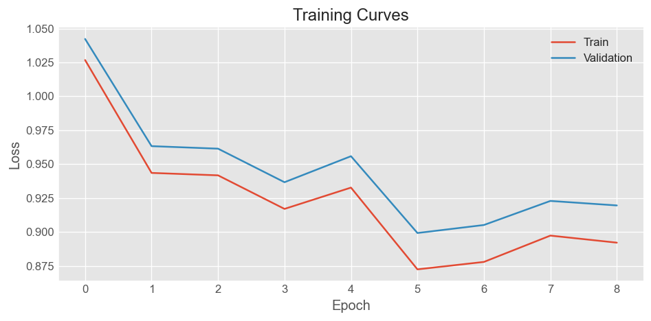

## Evaluation

```
Loaded checkpoint: chess_elo_v4_2e+06.pth
MAE    — White: 186.1  Black: 185.0  Combined: 185.5
Median — White: 152.3  Black: 153.4
Within 100 Elo: 34.1%
Within 200 Elo: 61.7%
Within 300 Elo: 80.5%
```

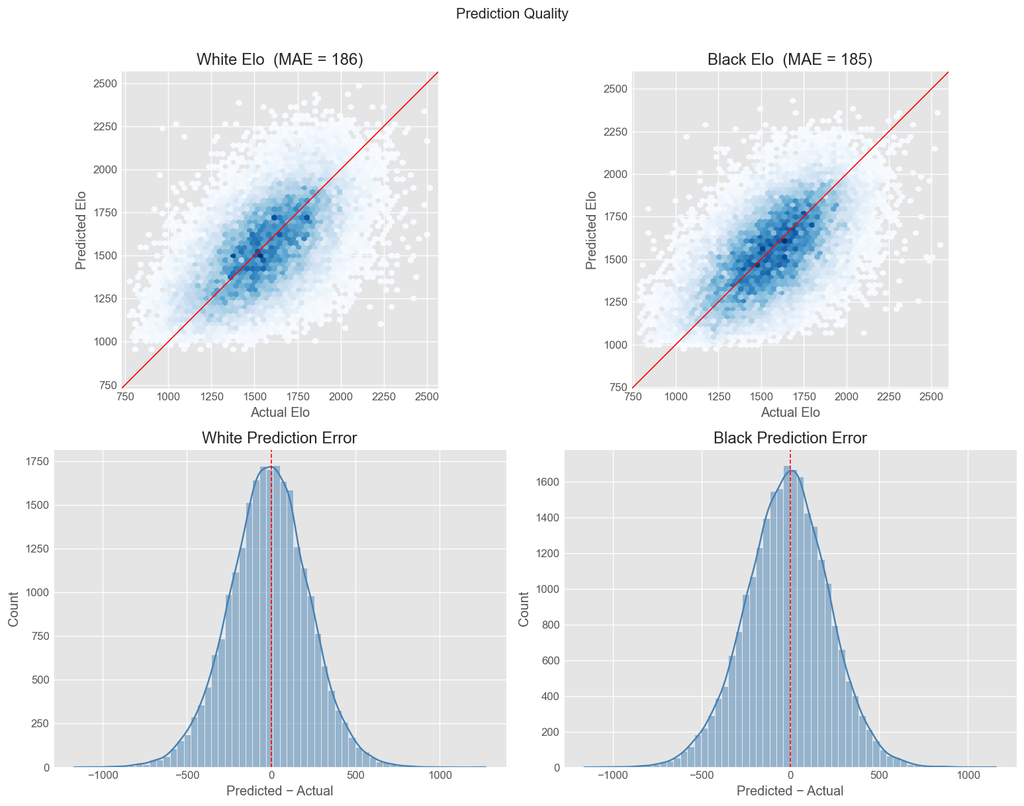

```
MAE by Elo bracket:
------------------------------------------
           (0, 1000]  MAE =   295  n = 571
        (1000, 1200]  MAE =   196  n = 3,437
        (1200, 1400]  MAE =   166  n = 9,023
        (1400, 1600]  MAE =   166  n = 13,493
        (1600, 1800]  MAE =   179  n = 13,032
        (1800, 2000]  MAE =   210  n = 7,158
        (2000, 2200]  MAE =   292  n = 1,760
        (2200, 2500]  MAE =   443  n = 254
        (2500, 4000]  MAE =   566  n = 6
```

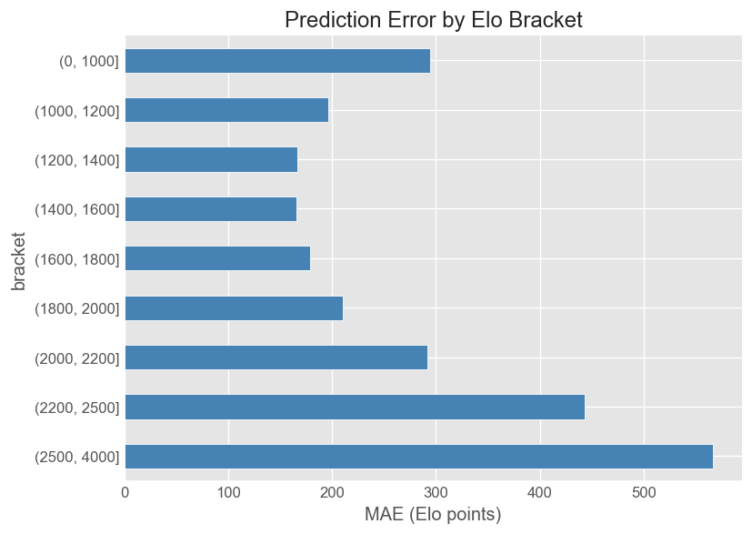

## Predicted Rating Distributions

One of the nicest things about the distribution output: instead of just getting a number, you see the full probability mass the model assigns across the rating range. A narrow peak means the model is confident; a wide spread means it's uncertain.

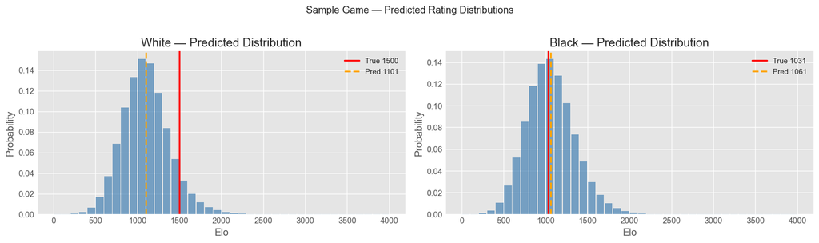

## Latent Space — t-SNE & PCA

Are games with similar Elo ratings close together in the model's internal representation?

```
Running t-SNE on 3000 vectors...
```

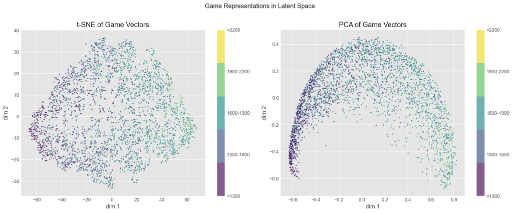

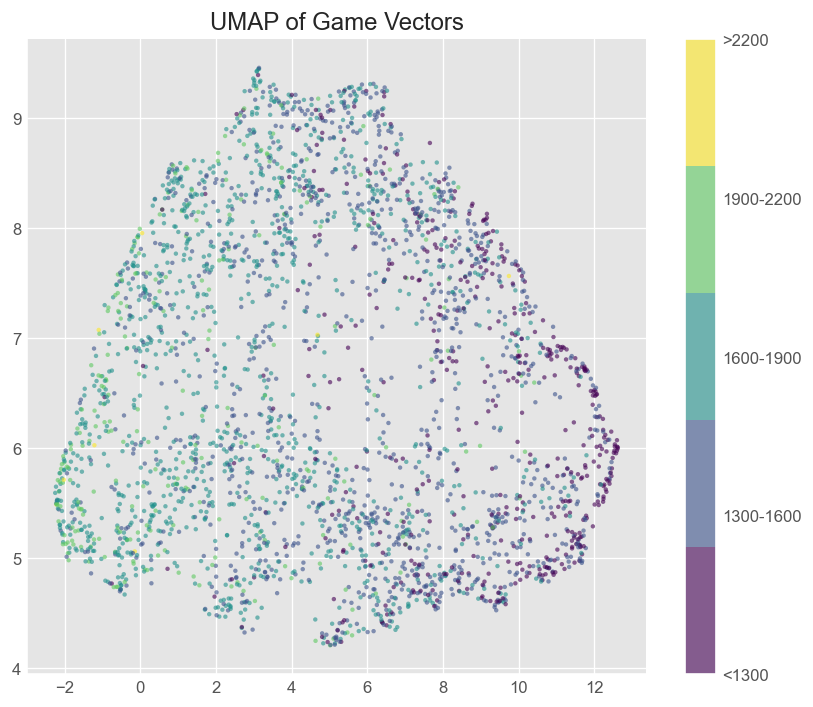

### AE Embedding Space

Same visualisation but using the raw AE embeddings before the main model sees them.

```
Running t-SNE on 3000 AE embeddings...
```

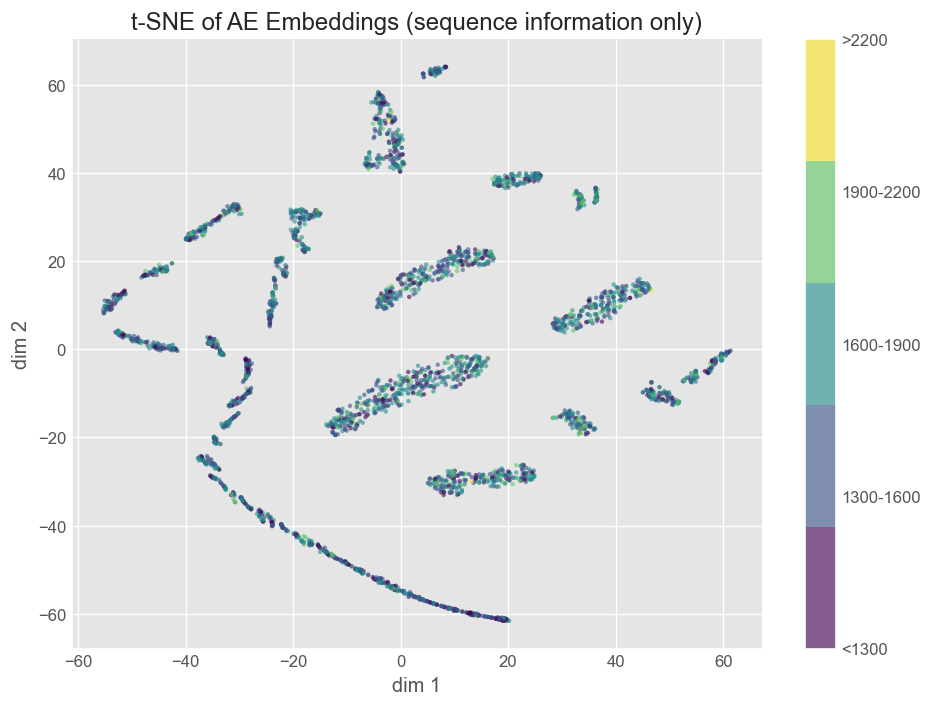

## Feature Group Importance

Zero out each feature group in turn and measure how much worse the MAE gets.

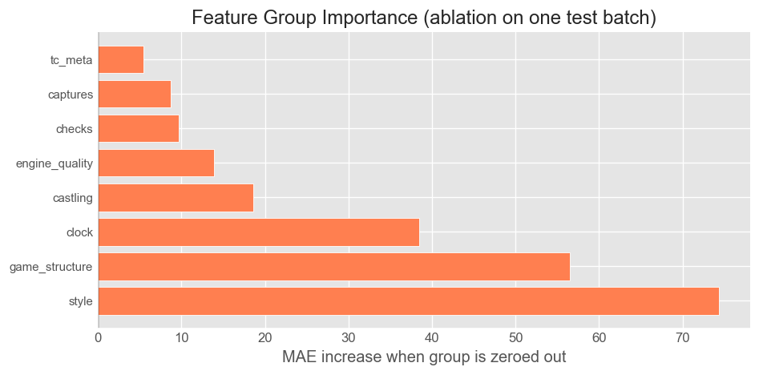

```
  style               Δ = +74.4
  game_structure      Δ = +56.5
  clock               Δ = +38.4
  castling            Δ = +18.6
  engine_quality      Δ = +13.9
  checks              Δ = +9.7
  captures            Δ = +8.7
  tc_meta             Δ = +5.5
```

## Opening Analysis (ECO codes)

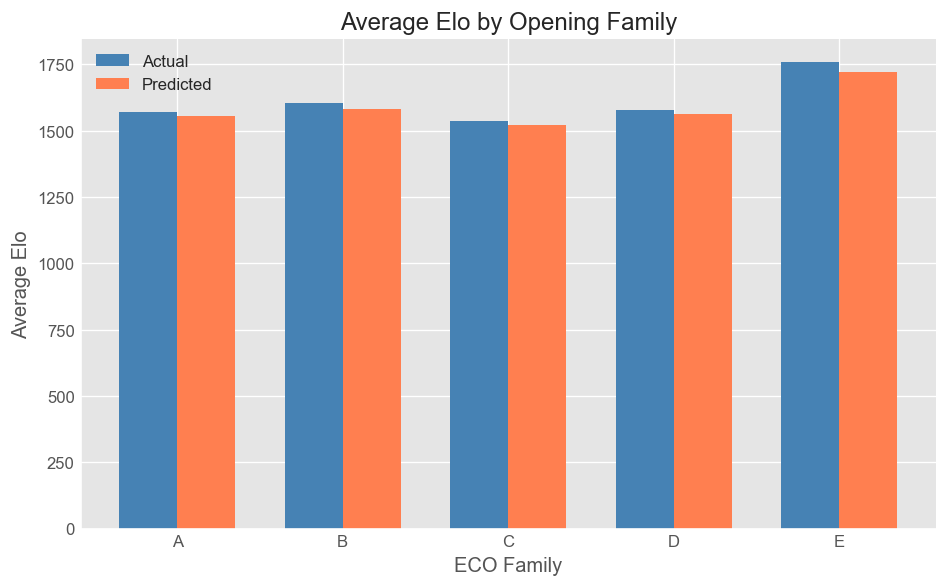

```
Top 5 highest-Elo ECO codes (min 10 games):
    E21  avg Elo: 1952  (n=10)
    E76  avg Elo: 1913  (n=12)
    B70  avg Elo: 1896  (n=10)
    C05  avg Elo: 1890  (n=11)
    B51  avg Elo: 1874  (n=12)

Bottom 5 lowest-Elo ECO codes (min 10 games):
    C20  avg Elo: 1394  (n=1217)
    C27  avg Elo: 1412  (n=56)
    C49  avg Elo: 1418  (n=22)
    C40  avg Elo: 1445  (n=661)
    C47  avg Elo: 1449  (n=68)
```

## Anomaly Detection

Games where the model's estimate differs most from actual rating — potential over/underperformers.

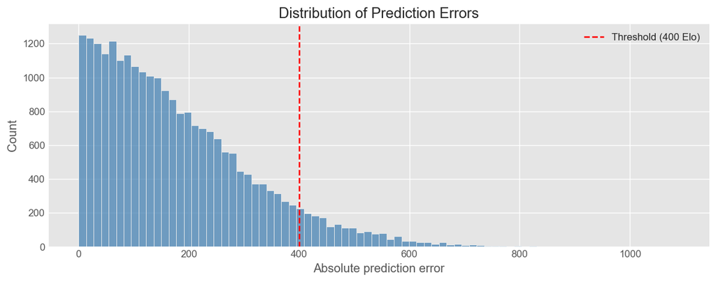

```
Flagged 1877 games with error > 400 Elo  (7.7%)

Top 15 OVERPERFORMERS  (model rates them higher than actual)
   Predicted      Actual      Diff
  --------------------------------
        2233        1145     +1088
        2086        1005     +1081
        2183        1265      +918
        1939        1042      +897
        1839         943      +896
        2194        1332      +861
        2090        1240      +850
        2116        1278      +838
        1818         986      +832
        1977        1153      +824
```

[output cut: 24 more lines]

## Single-Game Inference

Paste any PGN below and run the cell. Works with Lichess and chess.com exports. If the PGN has `[WhiteElo]` and `[BlackElo]` headers, the actual ratings are shown for comparison.

Note: this model was trained on Lichess ratings. Chess.com ratings tend to run ~100-200 points lower for the same strength player, so predictions on chess.com games may be slightly high.

```
=============================================
  White Elo   predicted:  1785   actual: 1546
  Black Elo   predicted:  1715   actual: 1534
=============================================
```

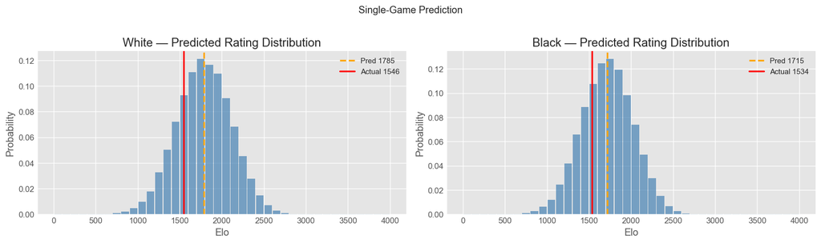

## Export

Press `Ctrl+S` to save the notebook, then run this cell.